# ABC Act Analysis

Jack Landry

6/22/2021

The Automatic BOOST to Communities Act, or the ABC Act, gives a total of $13,000 to every person in the United States annually until the end of the Coronavirus crisis. ‘’Every person’’ includes children (paid though who claims them as a dependent) and undocumented immigrants. The benefit is destributed monthly, with an initally $2,000 payment and $1,000 per month thereafter. This document assesses the bill’s hypothetical impact on poverty and the income distribution using data from the Current Population Survey’s Annual Social and Economic Supplement.

## Poverty Impacts of the ABC Act By Group

| Group | Status Quo Poverty | Reform Poverty | Poverty Reduction | Status Quo Deep Poverty | Reform Deep Poverty | Deep Poverty Reduction |
| --- | --- | --- | --- | --- | --- | --- |
| Overall | 13.9% | 0.6% | 13.2% | 4.9% | 0.1% | 4.8% |
| Children | 15.5% | 0.1% | 15.4% | 4.8% | 0.1% | 4.7% |
| Asian | 15.2% | 1.3% | 13.9% | 6.1% | 0.2% | 6% |
| Black | 22% | 0.7% | 21.3% | 7.5% | 0.1% | 7.5% |
| Hispanic | 21.5% | 0.6% | 20.9% | 6.1% | 0.1% | 5.9% |
| Other | 17.8% | 0.5% | 17.3% | 5.6% | 0.1% | 5.5% |
| White | 9.9% | 0.6% | 9.3% | 4% | 0.2% | 3.8% |

| Employment Status | Status Quo Poverty | Reform Poverty | Poverty Reduction | Status Quo Deep Poverty | Reform Deep Poverty | Deep Poverty Reduction |
| --- | --- | --- | --- | --- | --- | --- |
| Has Job | 7.8% | 0.4% | 7.5% | 2.4% | 0.1% | 2.3% |
| Retired | 16.6% | 1% | 15.6% | 6.7% | 0.2% | 6.4% |
| Unable to work | 31.1% | 1% | 30.1% | 10.1% | 0.2% | 9.9% |
| Unenployed | 22.8% | 1.1% | 21.6% | 8.2% | 0.2% | 8.1% |

| Family Size | Status Quo Poverty | Reform Poverty | Poverty Reduction | Status Quo Deep Poverty | Reform Deep Poverty | Deep Poverty Reduction |
| --- | --- | --- | --- | --- | --- | --- |
| 1 | 23.5% | 3.3% | 20.2% | 11.3% | 0.4% | 10.9% |
| 2 | 11.1% | 0.3% | 10.8% | 4.4% | 0.2% | 4.2% |
| 3 | 12.7% | 0.1% | 12.6% | 4% | 0% | 4% |
| 4 | 10.7% | 0.2% | 10.5% | 3.2% | 0.1% | 3.1% |
| 5 | 12.7% | 0.1% | 12.6% | 3% | 0% | 3% |
| 6 | 14.5% | 0% | 14.4% | 3.9% | 0% | 3.8% |
| 7 | 21.8% | 0% | 21.8% | 7.2% | 0% | 7.2% |
| 8+ | 22.2% | 0% | 22.2% | 3.8% | 0% | 3.8% |

Overall, the ABC Act would cause a 41,833,074 household poverty reduction, a 95.4% decrease (a 13.2 percentage point reduction).

## ABC Act’s Distributional Impact

The ABC ACT disproportunatly increases the income of low income families, even though there is no means testing or phase out. The mechanism for this effect is family size. Low income families are on average larger, so they see a larger benefit on average.

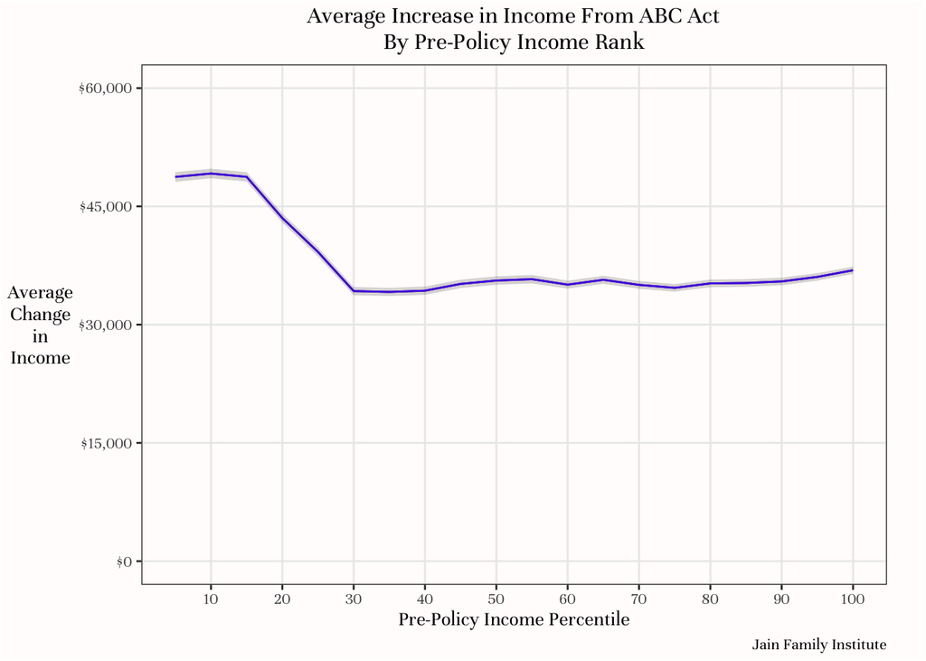

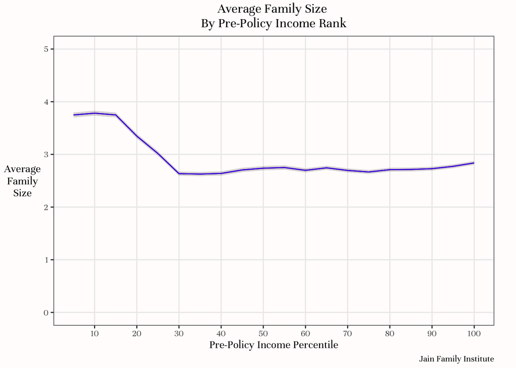

## Cost of Reform

Annually, the ABC act would cost approximately $4.1083 trillion dollars. This assumes none of the benefit is taxable, and no one changes their behavior in response to the benefit (e.g. reducing labor supply).